# Prediction Assignment Writeup

Peter Nicewicz

11/4/2017

# Executive Summary

This activity looks at the training and testing data sets for Weight Lifting Exercise Dataset. We split the training dataset into a training subset and a testing subset. The training subset is trained on three different models: random forests, support vector machines (SVM), and recursive partitioning (rpart). A confusion matrix is generated for the three models. The three models are then ensembled to see if an increased accuracy is achieve using generalized additive model (gam). The highest accuracy is achieved under the random forest model. The model is then applied to the original test set.

# Load library and data

```r
#Load libraries
library(caret)
library(randomForest)
```

```r
library(rpart)
library(e1071)
library(ggplot2)

#load files
training <- read.csv("pml-training.csv")
testing <- read.csv("pml-testing.csv")
```

# Process data

The first seven columns describe the user and the times and other identifying information associated with the dataset. This information is not necessary. We also perform a near-zero variance analysis on the training columns to see which columns have zero or near-zero variance (with the default 95/5 cut-off value for the most common value to the second most common value). We then calculate which fields have missing fields in the train set and remove those from both sets. Finally, the outcome variable is converted into factor format.

```r
#remove identifying columns
training <- training[, -seq(1,7)]
testing <- testing[, -seq(1,7)]

#identify and remove columns with near zero variance
zeroVar <- nearZeroVar(training)
training <- training[,-zeroVar]
testing <- testing[,-zeroVar]

#calculate which fields have missing values
cols <- unname(which(colSums(is.na(training)) > 0, arr.ind=TRUE))

#remove fields with missing values
training <- training[, -cols]
testing <- testing[, -cols]

training$classe <- as.factor(training$classe)
```

# Cross Validation

We will use random subsampling for our cross validation of the training dataset. 75% of the training set will be a sub-training set and the remaining 25% will be testing.

```r
#Perform cross Validation
#Split training set into random subtraining and subtesting sets
inTrain <- createDataPartition(training$classe, p=0.75, list=FALSE)

subTrain <- training[inTrain,]
subTest <- training[-inTrain,]
```

# Training models

We train three models: 1) random forest, 2) svm, and 3) rpart. The three models are run using their own packages rather than caret for processing speed. The sub testing data is then predicted on the three models and a confusion Matrix is created with the actual outcomes from the testing subtest. Show variable importance for the random forest model.

```r
#Model 1: Random forest
model1 <- randomForest(classe ~ ., data=subTrain)
model1predict <- predict(model1, newdata=subTest)
confusionMatrix(subTest$classe, model1predict)
```

```
## Confusion Matrix and Statistics
##
##           Reference
## Prediction    A    B    C    D    E
##          A 1394    0    0    0    1
##          B    0  949    0    0    0
##          C    0    3  851    1    0
##          D    0    0   11  793    0
##          E    0    0    0    6  895
##
## Overall Statistics
##
##                Accuracy : 0.9955
##                  95% CI : (0.9932, 0.9972)
##     No Information Rate : 0.2843
##     P-Value [Acc > NIR] : < 2.2e-16
##
##                   Kappa : 0.9943
##  Mcnemar's Test P-Value : NA
##
## Statistics by Class:
##
##                      Class: A Class: B Class: C Class: D Class: E
## Sensitivity            1.0000   0.9968   0.9872   0.9912   0.9989
## Specificity            0.9997   1.0000   0.9990   0.9973   0.9985
## Pos Pred Value         0.9993   1.0000   0.9953   0.9863   0.9933
## Neg Pred Value         1.0000   0.9992   0.9973   0.9983   0.9998
## Prevalence             0.2843   0.1941   0.1758   0.1631   0.1827
## Detection Rate         0.2843   0.1935   0.1735   0.1617   0.1825
## Detection Prevalence   0.2845   0.1935   0.1743   0.1639   0.1837
## Balanced Accuracy      0.9999   0.9984   0.9931   0.9943   0.9987
```

```r
#Model 2: SVM
model2 <- svm(classe ~ ., data=subTrain)
model2predict <- predict(model2, newdata=subTest)
confusionMatrix(subTest$classe, model2predict)
```

```
## Confusion Matrix and Statistics
##
##           Reference
## Prediction    A    B    C    D    E
##          A 1389    1    3    0    2
##          B   64  866   18    0    1
##          C    0   19  831    4    1
##          D    0    0   86  718    0
##          E    0    4   30   24  843
##
## Overall Statistics
##
##                Accuracy : 0.9476
##                  95% CI : (0.941, 0.9537)
##     No Information Rate : 0.2963
##     P-Value [Acc > NIR] : < 2.2e-16
##
##                   Kappa : 0.9336
##  Mcnemar's Test P-Value : NA
##
## Statistics by Class:
##
##                      Class: A Class: B Class: C Class: D Class: E
## Sensitivity            0.9560   0.9730   0.8585   0.9625   0.9953
## Specificity            0.9983   0.9793   0.9939   0.9793   0.9857
## Pos Pred Value         0.9957   0.9125   0.9719   0.8930   0.9356
## Neg Pred Value         0.9818   0.9939   0.9662   0.9932   0.9990
## Prevalence             0.2963   0.1815   0.1974   0.1521   0.1727
## Detection Rate         0.2832   0.1766   0.1695   0.1464   0.1719
## Detection Prevalence   0.2845   0.1935   0.1743   0.1639   0.1837
## Balanced Accuracy      0.9771   0.9762   0.9262   0.9709   0.9905
```

```r
#Model 3: Recursive partitioning for classification
model3 <-rpart(classe ~ ., data=subTrain)
model3predict <- predict(model3, newdata=subTest)
#The model prediction is in a different format than the other models -- pick the one that has the highest likelihood for every row
model3answer <- as.factor(colnames(model3predict)[apply(model3predict,1,which.max)])
confusionMatrix(subTest$classe, model3answer)
```

```
## Confusion Matrix and Statistics
##
##           Reference
## Prediction    A    B    C    D    E
##          A 1258   44   37   39   17
##          B  157  513   87   62  130
##          C   15   33  706   46   55
##          D   53   53  129  507   62
##          E   19   56  129   54  643
##
## Overall Statistics
##
##                Accuracy : 0.7396
##                  95% CI : (0.7271, 0.7518)
##     No Information Rate : 0.3063
##     P-Value [Acc > NIR] : < 2.2e-16
##
##                   Kappa : 0.6699
##  Mcnemar's Test P-Value : < 2.2e-16
##
## Statistics by Class:
##
##                      Class: A Class: B Class: C Class: D Class: E
## Sensitivity            0.8375   0.7339   0.6489   0.7161   0.7089
## Specificity            0.9597   0.8963   0.9610   0.9292   0.9355
## Pos Pred Value         0.9018   0.5406   0.8257   0.6306   0.7137
## Neg Pred Value         0.9305   0.9530   0.9057   0.9510   0.9340
## Prevalence             0.3063   0.1425   0.2219   0.1444   0.1850
## Detection Rate         0.2565   0.1046   0.1440   0.1034   0.1311
## Detection Prevalence   0.2845   0.1935   0.1743   0.1639   0.1837
## Balanced Accuracy      0.8986   0.8151   0.8049   0.8227   0.8222
```

# Ensemble model

```r
#Create a data frame with the answers for each of the models and the test subtest answer
combinedTestData <- data.frame(model1=model1predict, model2=model2predict, model3=model3answer, answer=subTest$classe)
#Train the ensembled model
comb.fit <- suppressWarnings(train(answer ~ ., method="gam", data=combinedTestData))
#Predict using the combined test subtest
comb.pred.test <- predict(comb.fit, combinedTestData)
#Generate confusion matrix
confusionMatrix(subTest$classe, comb.pred.test)
```

```
## Confusion Matrix and Statistics
##
##           Reference
## Prediction    A    B    C    D    E
##          A 1394    1    0    0    0
##          B    0  949    0    0    0
##          C    0  855    0    0    0
##          D    0  804    0    0    0
##          E    0  901    0    0    0
##
## Overall Statistics
##
##                Accuracy : 0.4778
##                  95% CI : (0.4637, 0.4919)
##     No Information Rate : 0.7157
##     P-Value [Acc > NIR] : 1
##
##                   Kappa : 0.331
##  Mcnemar's Test P-Value : NA
##
## Statistics by Class:
##
##                      Class: A Class: B Class: C Class: D Class: E
## Sensitivity            1.0000   0.2704       NA       NA       NA
## Specificity            0.9997   1.0000   0.8257   0.8361   0.8163
## Pos Pred Value         0.9993   1.0000       NA       NA       NA
## Neg Pred Value         1.0000   0.3525       NA       NA       NA
## Prevalence             0.2843   0.7157   0.0000   0.0000   0.0000
## Detection Rate         0.2843   0.1935   0.0000   0.0000   0.0000
## Detection Prevalence   0.2845   0.1935   0.1743   0.1639   0.1837
## Balanced Accuracy      0.9999   0.6352       NA       NA       NA
```

The combined model only yields a 47.7% accuracy. We should disregard, and go with the random forest model.

# Plot the random forest model

The two most important variable in the random forest model are the roll_belt and yaw_belt. We construct a simple plot with roll_belt (x) against yaw_belt (y), with the color being the outcome (classe).

```r
#show variable importance for model 1
varImp(model1)
```

```
##                        Overall
## roll_belt            923.36273
## pitch_belt           503.02815
## yaw_belt             661.20987
## total_accel_belt     177.24466
## gyros_belt_x          75.39902
## gyros_belt_y          81.82002
## gyros_belt_z         231.97113
## accel_belt_x          88.00699
## accel_belt_y          93.87197
## accel_belt_z         296.31119
## magnet_belt_x        187.76531
## magnet_belt_y        315.27400
## magnet_belt_z        298.55180
## roll_arm             233.04552
## pitch_arm            129.24332
## yaw_arm              176.79836
## total_accel_arm       75.27035
## gyros_arm_x           97.79581
## gyros_arm_y          105.21540
## gyros_arm_z           46.16023
## accel_arm_x          190.18482
## accel_arm_y          116.79004
## accel_arm_z          102.79845
## magnet_arm_x         197.29032
## magnet_arm_y         170.16546
## magnet_arm_z         144.43020
## roll_dumbbell        327.89825
## pitch_dumbbell       129.90310
## yaw_dumbbell         199.12026
## total_accel_dumbbell 188.71094
## gyros_dumbbell_x     100.16205
## gyros_dumbbell_y     182.31220
## gyros_dumbbell_z      65.09756
## accel_dumbbell_x     185.29725
## accel_dumbbell_y     308.64156
## accel_dumbbell_z     243.29461
## magnet_dumbbell_x    377.25483
## magnet_dumbbell_y    496.93502
## magnet_dumbbell_z    571.45357
## roll_forearm         448.93551
## pitch_forearm        573.12863
## yaw_forearm          121.32587
## total_accel_forearm   84.52108
## gyros_forearm_x       57.77642
## gyros_forearm_y       99.26465
## gyros_forearm_z       64.63522
## accel_forearm_x      254.19288
## accel_forearm_y      106.34347
## accel_forearm_z      181.87160
## magnet_forearm_x     158.82090
## magnet_forearm_y     177.26781
## magnet_forearm_z     212.14763
```

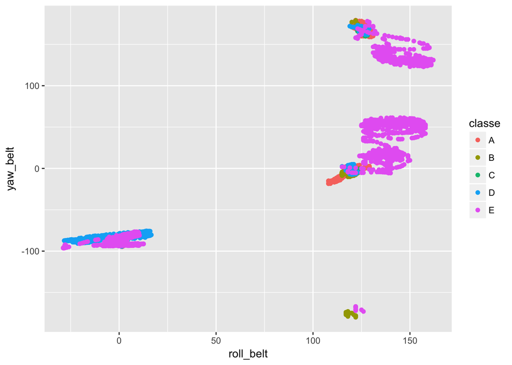

```r
p <- qplot(roll_belt, yaw_belt, col=classe, data=subTrain)
p
```

# Test with testing sample

We then apply the random forest model (model 1) to the actual testing set

```r
prediction <- predict(model1, newdata=testing)
```